# Analysis Serlo event log

This document provides a brief analysis of the serlo event-log and the editing-history on serlo.org.

# 1 Fundamental remarks

- We look at all edits recorded by the event log, beginning with 2015 and for authors beginning 2016.
- We count as an edit the actions defined by [this document](https://docs.google.com/spreadsheets/d/1WoNiWyXJRckC1eNwed6et-7N02f2mlx9iMKF87F4f6I/edit#gid=1937612395) (last line). These are `"entity/link/remove", "entity/link/remove", "entity/revision/add", "entity/create".`
- In the course of this analysis we use the term active author. An active author at time $t$ is someone, who had 10 or more edits some time in the last 90 days.

# 2 Analysis of edit-count

We start by looking at the edits per day, plotted since 2015:

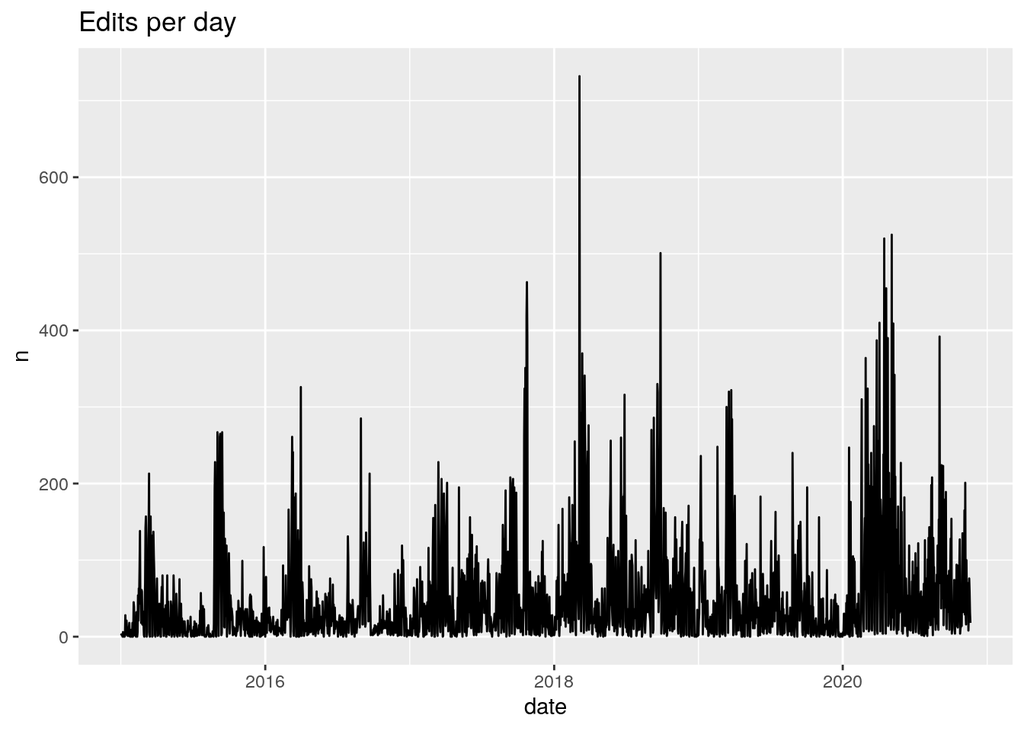

```r
edits_per_day <- events %>%
  count(date) %>%
  complete(date = full_seq(date, period = 1), fill = list(n = 0))

ts_edits <- ts(edits_per_day$n, start= min(edits_per_day$date), frequency = 365.25)

edits_per_day %>%
  ggplot(aes(x=date, y=n)) +
  geom_line() +
  ggtitle("Edits per day")
```

We see that edits differ quite a lot in different days and there seems to be a continuous number of edits done, interrupted by some spikes, probably corresponding to redactional days, sprints,…

One can look at a moving average for further analysis and a better view:

here you would have a cool plugin, that I deactivated for the html-export.

```r
ui <- fluidPage(
    # Sidebar with a slider input for number of bins
    sidebarLayout(
        sidebarPanel(
            sliderInput("days",
                        "Days",
                        min = 1,
                        max = 100,
                        value = 31)
        ),

        # Show a plot of the generated distribution
        mainPanel(
           plotOutput("distPlot")
        )
    )
)

server <- function(input, output) {
    output$distPlot <- renderPlot({
        edits_per_day %>% mutate(roll_mean = rollmean(n, input$days, fill=NA)) %>%
        drop_na(roll_mean) %>%
        ggplot(aes(x=date, y=roll_mean)) + geom_line() + xlab("Date") + ylab("Number of edits with rolling mean")

    })
}

shinyApp(ui = ui, server = server)
```

Interesting insights give moving average over a year and the one over a month with the different years in comparison:

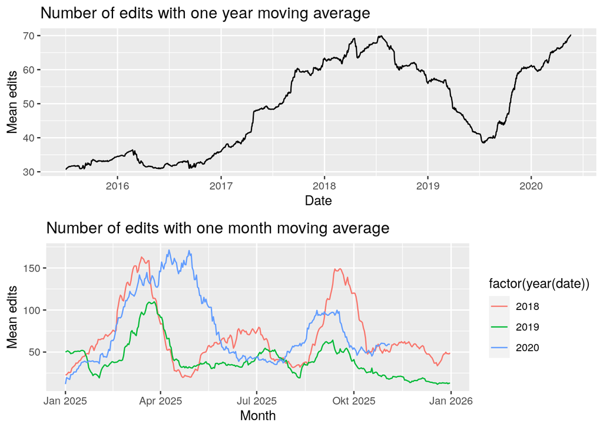

```r
moving_average_365 <- edits_per_day %>% mutate(roll_mean = rollmean(n, 365, fill=NA)) %>%
  drop_na(roll_mean) %>%
  ggplot(aes(x=date, y=roll_mean)) +
  geom_line() +
  xlab("Date") +
  ylab("Mean edits") +
  ggtitle("Number of edits with one year moving average")

moving_average_comparison_31 <- edits_per_day %>% mutate(roll_mean = rollmean(n, 31, fill=NA)) %>%
  drop_na(roll_mean) %>%
  filter(year(date) > 2017) %>%
  ggplot(aes(x=make_date(2025, month(date), day(date)), y=roll_mean, colour=factor(year(date)))) +
  geom_line() +
  ylab("Mean edits") +
  ggtitle("Number of edits with one month moving average") +
  xlab("Month")

grid.arrange(moving_average_365, moving_average_comparison_31, ncol = 1, nrow = 2)
```

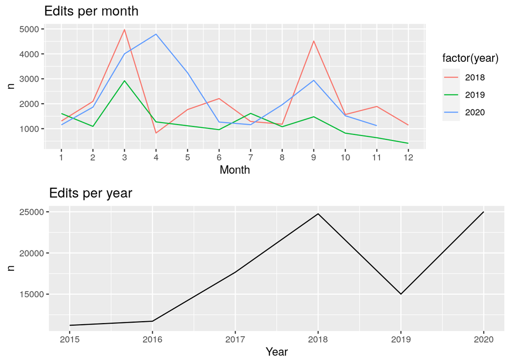

```r
edits_per_month <- events %>%
  count(month=month(date), year=year(date))%>%
  filter(year > 2017) %>%
  ggplot(aes(x=month, y=n, colour=factor(year))) +
  geom_line() +
  ggtitle("Edits per month") +
  xlab("Month") +
  scale_x_continuous(breaks=1:12)


edits_per_year <- events %>%
  count(year=year(date)) %>%
  ggplot(aes(x=year, y=n)) +
  geom_line() +
  ggtitle("Edits per year") +
  xlab("Year")


grid.arrange(edits_per_month, edits_per_year, ncol = 1, nrow = 2)
```

## 2.1 2.2 Author-analysis

Now we come to the analysis of the authors that make edits. We only look at the time since 2016.

```r
events %<>% filter(year(date)>2015)
```

Active authors are authors having 10 or more edits in 90 days. Their evolution over time:

```r
active_authors_per_day <- cum_active_authors %>% group_by(date)  %>% summarize(n=n())
```

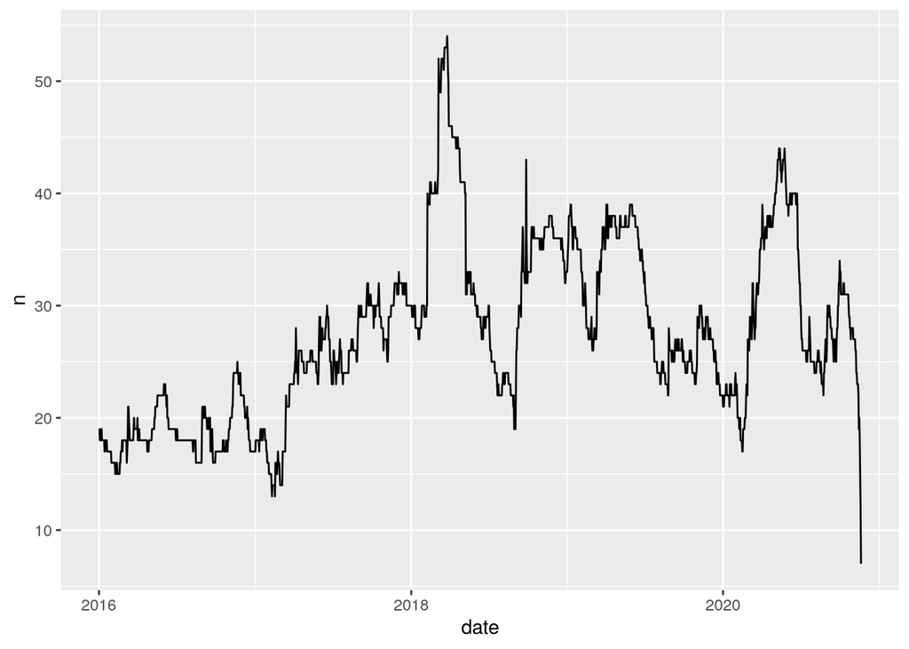

```r
active_authors_per_day %>% ggplot(aes(x=date, y=n)) + geom_line()
```

Some observations:

- 0.9665134% of all edits since 2016 are made by authors while they are being active (having more than 9 edits in the last 90 days).
- The most active 20% of all authors are responsible for 0.8989029 % of all edits. The top 10% still for 0.7381607% of all edits. That can also the case because there are many authors with only one edit.
- But it shows, that the top 20% of active authors are also responsible for 0.7530218 % of all edits made by active authors and for 0.7278057% of all edits.
- This is also very stable during the different years.

Looking at what active authors do while being active:

```r
#Events active authors did while being active
events_by_active_authors <- events %>% inner_join(cum_active_authors, by=c("date", "actor_id"))
```

In the time they are active authors usually have as many edits as they edit different content-objects. The ratio is:

```r
actor_uuid_ids <- events_by_active_authors %>% group_by(actor_id, uuid_id) %>% summarize(n=n()) %>% group_by(actor_id) %>% summarise(ratio = sum(n)/n())
actor_uuid_ids %>%summarize(mean = mean(ratio))
```

```
## # A tibble: 1 x 1
##    mean
##   <dbl>
## 1  1.00
```

Authors don’t really tend to spend multiple edits on one content-object, but instead to edit a multiply of content. This is very homogeneous with a standard-deviation of 0.0036982 and 0.9697885% of authors for which this is exactly equal to 1. I look at the other ones. For them their edits are

```r
events %>% inner_join(events_by_active_authors %>% group_by(actor_id, uuid_id) %>% summarize(n=n()) %>% filter(n!=1), by=c("uuid_id", "actor_id")) %>% group_by(actor_id, uuid_id, date) %>% summarise(n=n())
```

```
## # A tibble: 124 x 4
## # Groups:   actor_id, uuid_id [70]
##    actor_id uuid_id date           n
##       <int>   <int> <date>     <int>
##  1      266    2423 2017-09-22     2
##  2      266    2427 2017-09-22     2
##  3      266    8911 2017-09-19     3
##  4      266   10973 2017-09-04     4
##  5      266   14623 2016-05-04     5
##  6      266   15401 2017-11-27     3
##  7      266   21782 2017-11-27     3
##  8      266   51983 2016-02-25     1
##  9      266   51983 2016-02-26     1
## 10      266   51989 2016-02-25     1
## # … with 114 more rows
```

```r
#uuids whete edits on one date, look how many with one, how many without
```

# 3 Temporal analysis

We now switch to a mainly temporal analysis of author-activity.

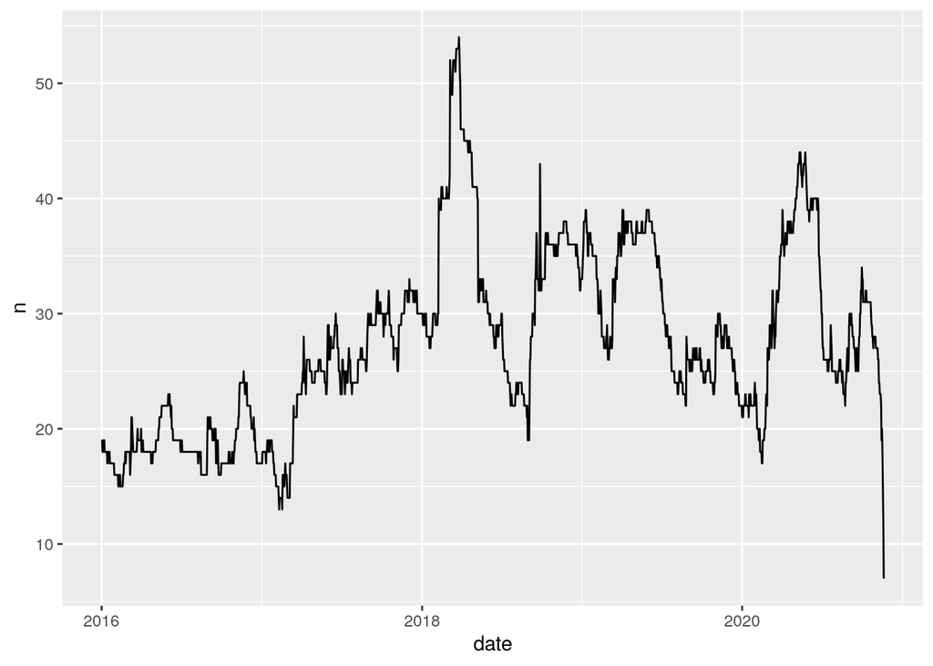

```r
active_authors_per_day %>% ggplot(aes(x=date, y=n)) +geom_line()
```

Interesting are also the sum of all edits of active authors in the last 90 days, as well as the mean edits of active authors in the last 90 days:

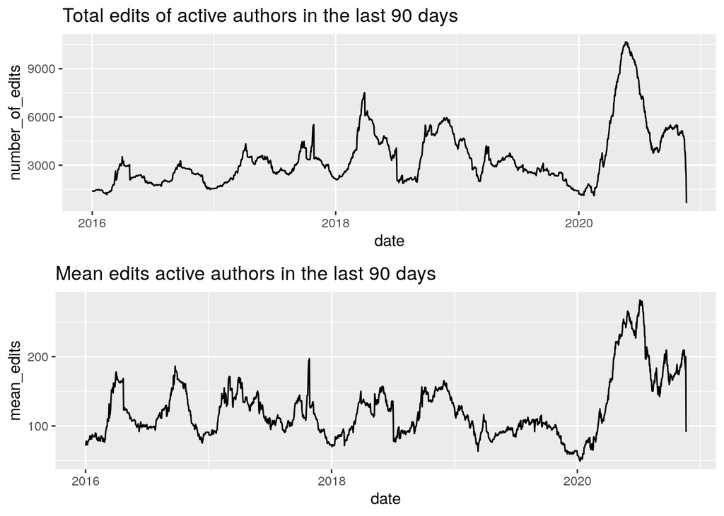

Both being accumulations over 90 days seem relatively stable and without much “noise”. We can also look at the mean number of authors in a 31 day moving average:

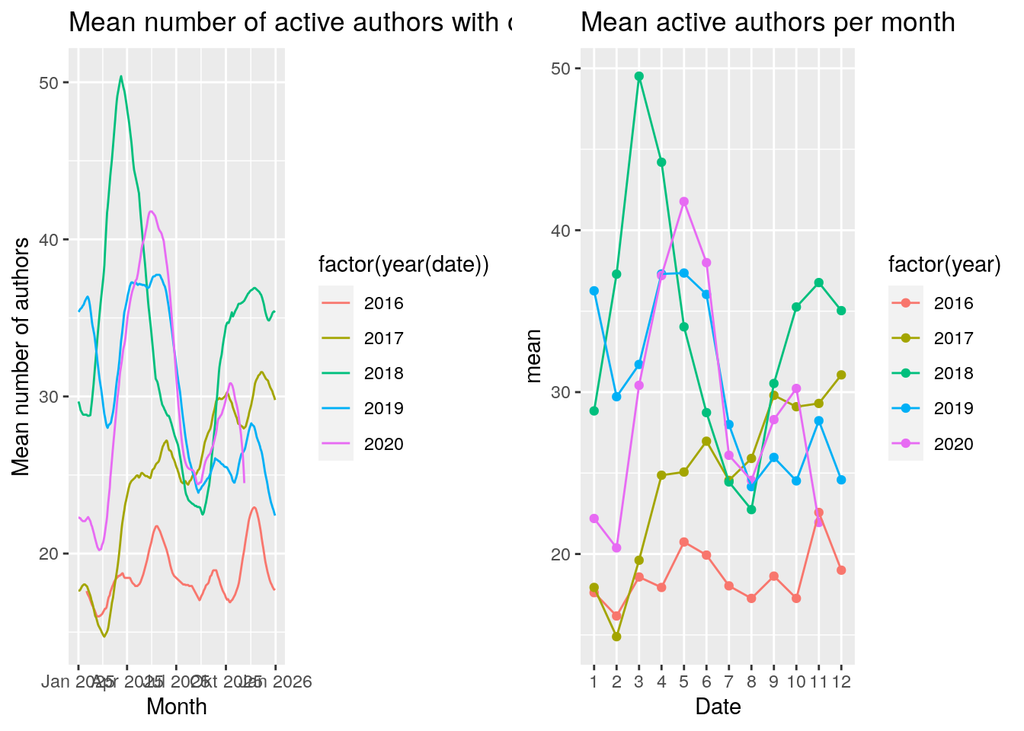

```r
author_moving_average_comparison_31 <- active_authors_per_day %>% mutate(roll_mean = rollmean(n, 31, fill=NA)) %>%
  drop_na(roll_mean) %>%
  ggplot(aes(x=make_date(2025, month(date), day(date)), y=roll_mean, colour=factor(year(date)))) +
  geom_line() +
  ylab("Mean number of authors") +
  ggtitle("Mean number of active authors with one month moving average") +
  xlab("Month")

authors_moving_average_365 <- active_authors_per_day %>% mutate(roll_mean = rollmean(n, 365, fill=NA)) %>%
  drop_na(roll_mean) %>%
  ggplot(aes(x=date, y=roll_mean)) +
  geom_line() +
  xlab("Date") +
  ylab("Mean number of authors") +
  ggtitle("Mean number of active authors with one year moving average")


active_authors_per_month <- active_authors_per_day %>%
  group_by(month = month(date),year= year(date)) %>%
  summarize(mean=mean(n))  %>%
  ggplot(aes(x=factor(month), y=mean, colour=factor(year))) +
  geom_point() +
  geom_line(aes(group = year)) +
  ggtitle("Mean active authors per month") +
  xlab("Date")
grid.arrange(author_moving_average_comparison_31, active_authors_per_month, ncol = 2, nrow = 1)
```

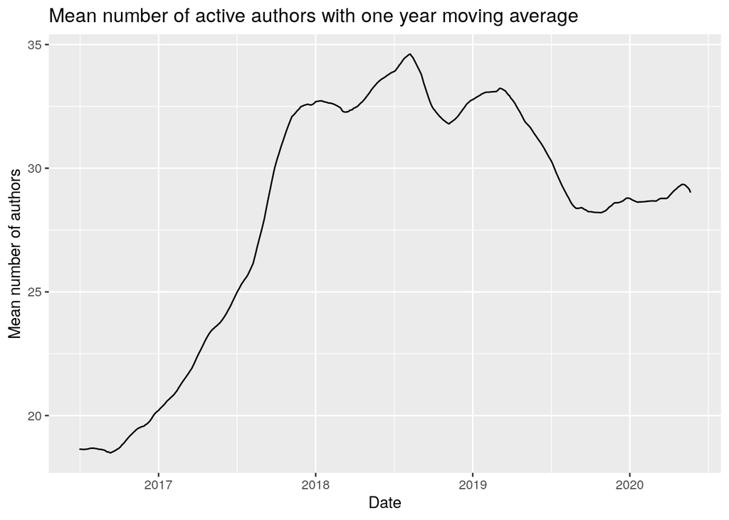

```r
authors_moving_average_365
```

One question we can ask is how long do active authors stay like this. First we look at the total elapsed time between the first and last edit:

```r
elapsed_time <- cum_active_authors %>%
  group_by(actor_id) %>%
  summarize(timespan=max(date)-min(date))
```

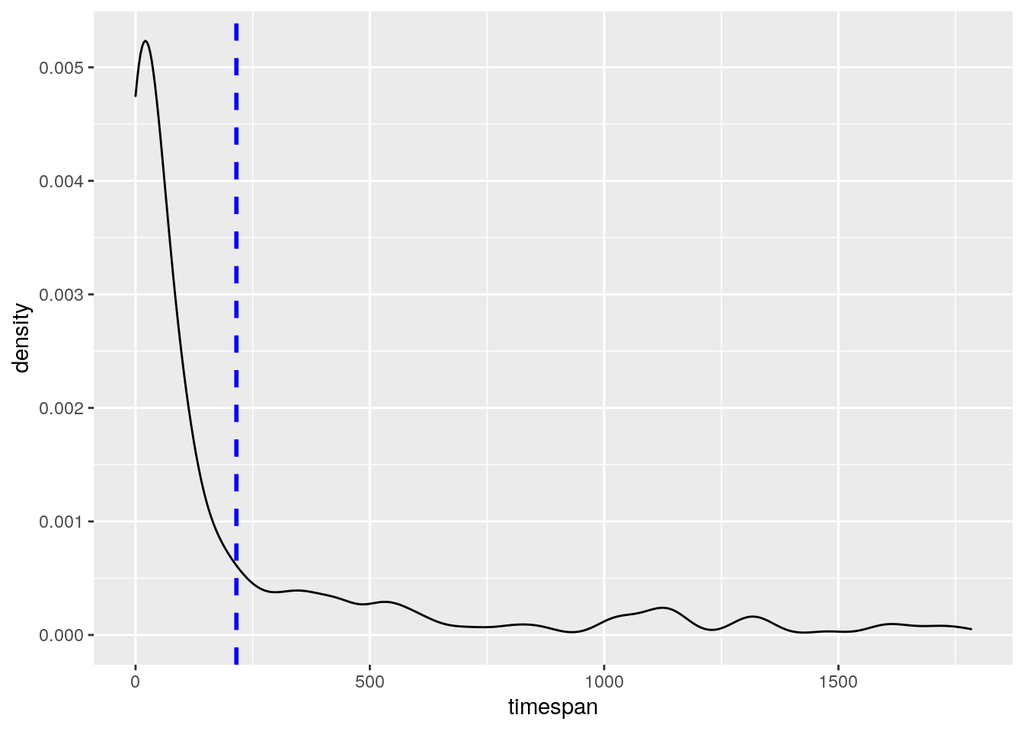

```r
elapsed_time %>% ggplot(aes(timespan)) + geom_density() + geom_vline(aes(xintercept=mean(timespan)),
            color="blue", linetype="dashed", size=1)
```

```r
#überlegen ob gucken wieviele prozent über dem mean
```

At least 0.2409639 of all authors have a total time between first and last edit greater than the mean of 215.2379518

More interesting are the consecutive timespans in which an author stays as active author, so the time between first and last edit during which the author consecutively has an active status. That allows for values less than 90:

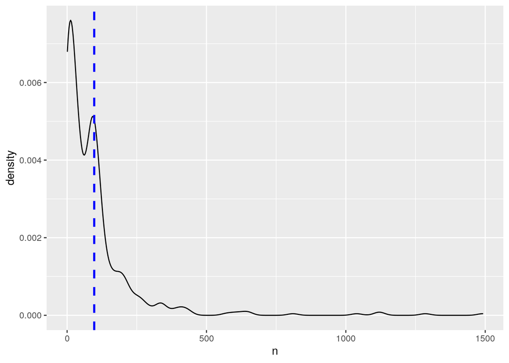

```r
consecutive_times <- cum_active_authors %>% group_by(actor_id, seq_id = cumsum(c(1, as.numeric(diff(date))) != 1)) %>% count(seq_id)

consecutive_times %>% ggplot(aes(n)) + geom_density() + geom_vline(aes(xintercept=mean(n)),
            color="blue", linetype="dashed", size=1)
```

The mean consecutive time is 97.2644135 with some people having an active status pretty much since the beginning of 2016.

Here are some more research questions possible: - How many edits do authors do in their periods of activity (while being counted active) - Where do they edit? Merge with data about topic - If we make the notion of activity-phases exact that allows interesting modelling: having an author either as active or non-active and assuming a pseudo exponential for the time we can look if the behavior is really that bursty and what correlates with longer activity-times/what we can do to promote them.

### 3.0.1 Smoothing of data and trends

We now come to a time-series analysis of the author-data. For that we convert the active authors per day to a R-time-series.

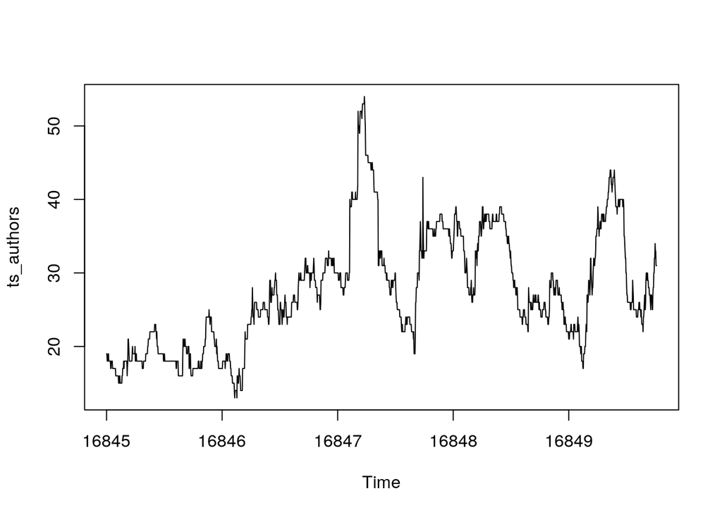

```r
ts_authors <- ts(active_authors_per_day$n[45:length(active_authors_per_day$n)-45], start= active_authors_per_day$date[45], frequency = 365.25)
plot.ts(ts_authors)
```

One easy way to get a “smoothing” is via a moving average:

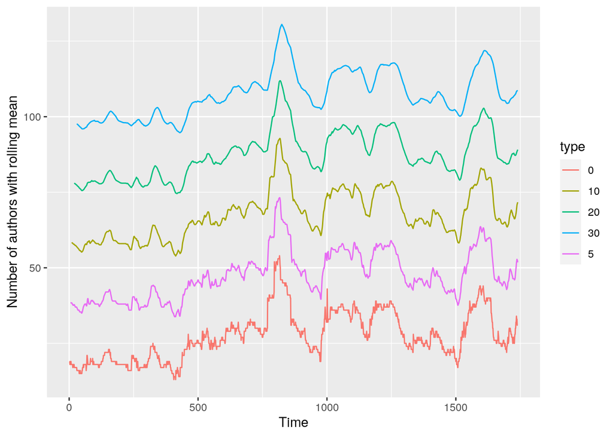

```r
size <- length(ts_authors)
pmfs <- data.frame(
  type = c(replicate(size, "0"), replicate(size, "5"), replicate(size, "10"), replicate(size, "20"), replicate(size, "30")),
  values = c(ts_authors, SMA(ts_authors, n=5)+20,
   SMA(ts_authors, n=10)+40, SMA(ts_authors, n=20)+60, SMA(ts_authors, n=30)+80), x_values=c(1:size))


ggplot(pmfs, aes(x= x_values, y=values, colour=type)) + geom_line() + xlab("Time") + ylab("Number of authors with rolling mean")
```

One natural choice here for KPIs, which we also looked at above is the one-month moving average, which seems to cancel out a lot of the noise.

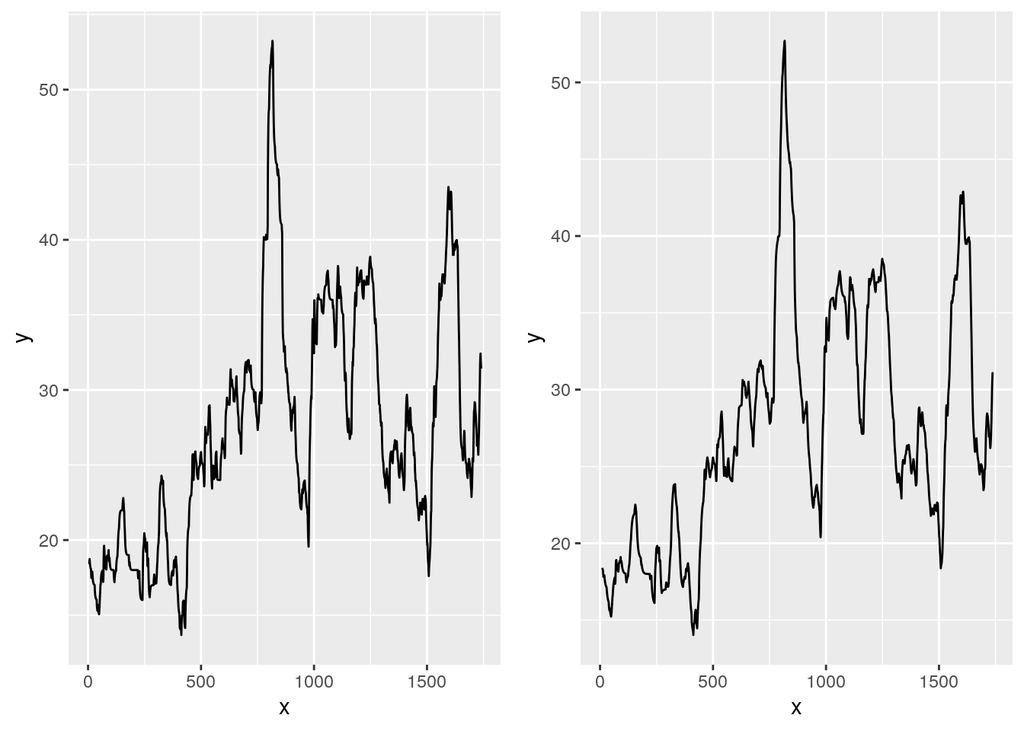

```r
ema5 <- data.frame(x=1:length(ts_authors), y= EMA(ts_authors, 5))
ema10 <- data.frame(x=1:length(ts_authors), y= EMA(ts_authors, 10))
ema5 <- ema5 %>% ggplot(aes(x,y)) + geom_line()
ema10 <- ema10 %>% ggplot(aes(x,y)) + geom_line()
grid.arrange(ema5, ema10, ncol = 2, nrow = 1)
```

Now important questions are trend and periodicity. There are unconclusive messages here. I use a box-Jenkins-approach and first try a detrending by just taking the daily differences:

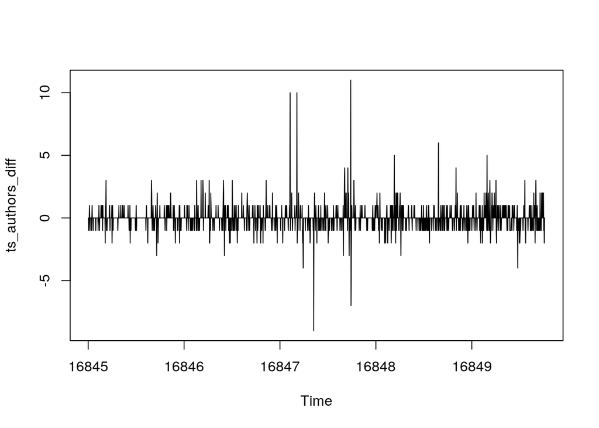

```r
ts_authors_diff = diff(ts_authors)
plot(ts_authors_diff)
```

This appears stationary and the mean is also with 0.0069005 quite near to zero. I test the existence of a unit root with the Augmented Dickey–Fuller test. I get:

```r
adf.test(ts_authors_diff, alternative="stationary")
```

```
##
##  Augmented Dickey-Fuller Test
##
## data:  ts_authors_diff
## Dickey-Fuller = -10.708, Lag order = 12, p-value = 0.01
## alternative hypothesis: stationary
```

So we can reject the existence of a unit-root. the KPSS-test gives:

```r
kpss.test(ts_authors_diff)
```

```
##
##  KPSS Test for Level Stationarity
##
## data:  ts_authors_diff
## KPSS Level = 0.037824, Truncation lag parameter = 8, p-value = 0.1
```

Which is good. A first difference seems enough and this is what we also get by automated ndiffs in the forecast-package. We could try now fitting an ARMA-model. But still the autocorrelations is:

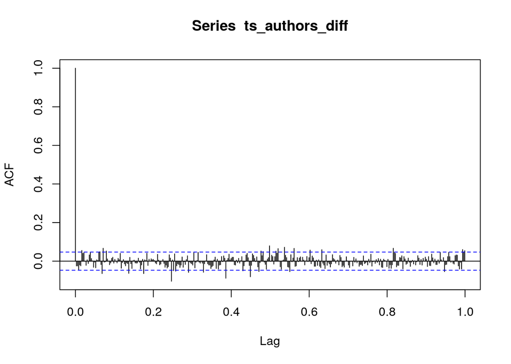

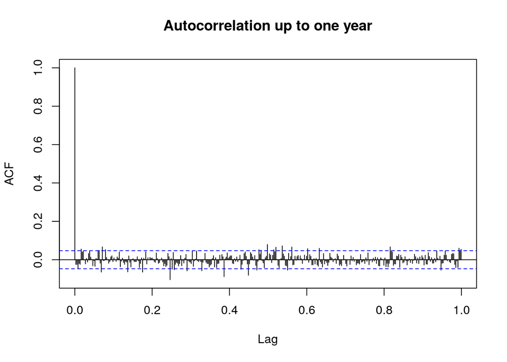

```r
plot(acf(ts_authors_diff, lag.max=365),  main="Autocorrelation up to one year")
```

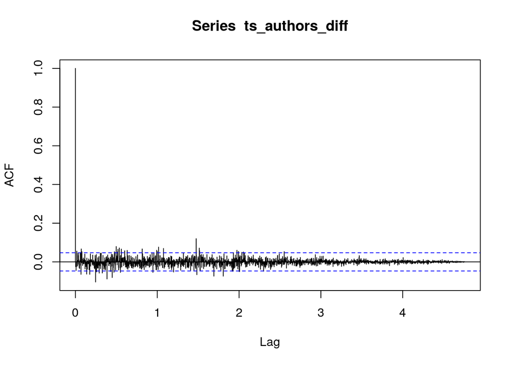

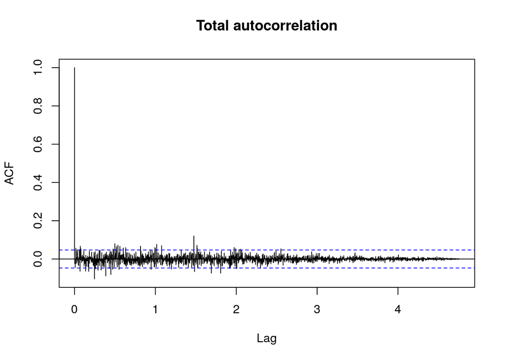

```r
plot(acf(ts_authors_diff, lag.max=length(ts_authors_diff)), main="Total autocorrelation")
```

```r
kpss.test(ts_authors, null="Trend")
```

```
##
##  KPSS Test for Trend Stationarity
##
## data:  ts_authors
## KPSS Trend = 1.7231, Truncation lag parameter = 8, p-value = 0.01
```

Thats also what shows in the plot of residuals.

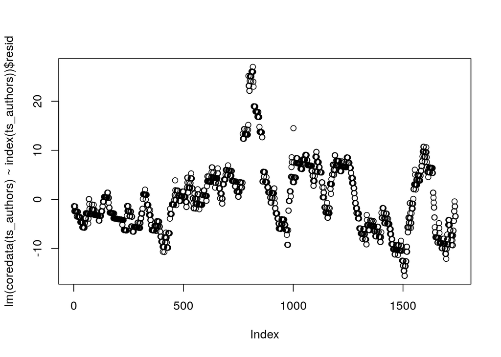

```r
plot(lm(coredata(ts_authors) ~ index(ts_authors))$resid)
```

Further we can use a standard R-decomposition:

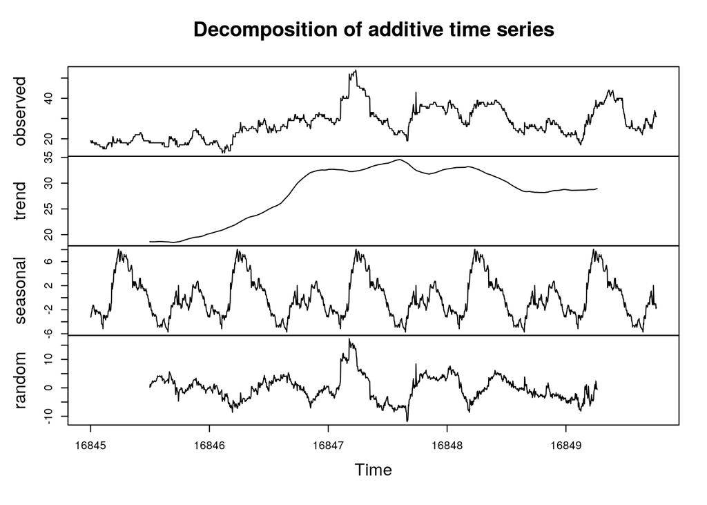

```r
plot(decompose(ts_authors))
```

There seems to be maybe a plateau after 0.4. We can plot that:

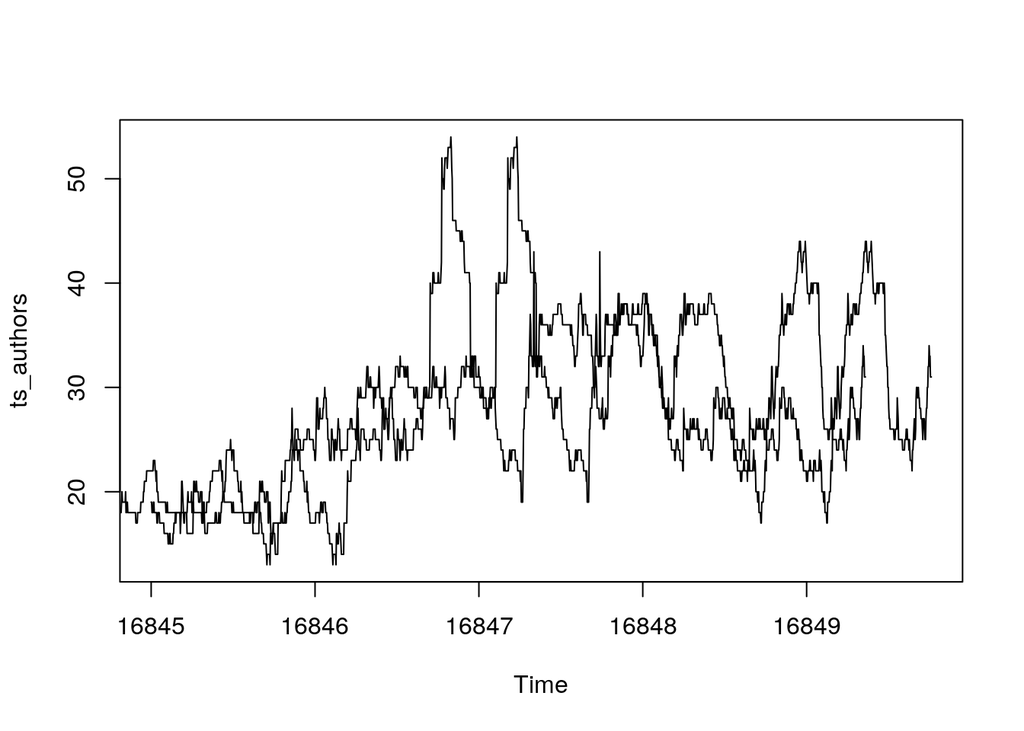

```r
plot.ts(ts_authors)
lines(stats::lag(ts_authors, ceiling(0.4*365.25)))
```

–> look what already done, add exponential smoothing and autocorrelation

# 4 Analysis of content

```r
edits_on_content <- events %>% group_by(uuid_id) %>% summarize(n=n()) %>% arrange(desc(n))
```

Since 2016 most content in the event log has been edited 1.0016382 times

Interessante Fragen: - welche sind die meist bearbeiteten Inhalte? Sind die identisch mit den meist beuschten? (GoogleAnalytics), durchschnittliche edits - wo arbeiten AUtor:innen, an wievielen Artikeln im Durschnitt, Varianz - wo fangen autor:innen an z uarbeiten, wo gehen sie hin? Gibt es “typische Wege”